# DriverTypeColour

DanielaFontes

Thursday, April 23, 2015

iCO2 March Campaign 2014

# Europe data

```
##               DriverID  X..inf...100.       X..100...90.
##  '100000521594761': 1   Min.   :0.001637   Min.   :0.000000
##  '100000537154403': 1   1st Qu.:0.009581   1st Qu.:0.002254
##  '100001012418673': 1   Median :0.011413   Median :0.003634
##  '100001053594687': 1   Mean   :0.019275   Mean   :0.004225
##  '100001376345011': 1   3rd Qu.:0.027839   3rd Qu.:0.005362
##  '100001563860693': 1   Max.   :0.053887   Max.   :0.014166
##  (Other)          :16
##   X..90...80.        X..80...70.         X..70...60.
##  Min.   :0.001277   Min.   :0.0008753   Min.   :0.002429
##  1st Qu.:0.003262   1st Qu.:0.0051502   1st Qu.:0.004833
##  Median :0.005261   Median :0.0076949   Median :0.007955
##  Mean   :0.006361   Mean   :0.0081555   Mean   :0.008888
##  3rd Qu.:0.009254   3rd Qu.:0.0111452   3rd Qu.:0.012876
##  Max.   :0.016146   Max.   :0.0181953   Max.   :0.023762
##
##   X..60...50.        X..50...40.        X..40...30.
##  Min.   :0.003273   Min.   :0.005728   Min.   :0.009343
##  1st Qu.:0.007758   1st Qu.:0.010883   1st Qu.:0.023788
##  Median :0.012960   Median :0.021394   Median :0.027776
##  Mean   :0.013645   Mean   :0.019409   Mean   :0.026686
##  3rd Qu.:0.018686   3rd Qu.:0.026648   3rd Qu.:0.031734
##  Max.   :0.030008   Max.   :0.033206   Max.   :0.038583
##
##   X..30...20.       X..20...10.        X..10..0.          X.0..10.
##  Min.   :0.01448   Min.   :0.02382   Min.   :0.06026   Min.   :0.1927
##  1st Qu.:0.03559   1st Qu.:0.07054   1st Qu.:0.18661   1st Qu.:0.2297
##  Median :0.04541   Median :0.07884   Median :0.24285   Median :0.2794
##  Mean   :0.04186   Mean   :0.07610   Mean   :0.24624   Mean   :0.3085
##  3rd Qu.:0.05104   3rd Qu.:0.08731   3rd Qu.:0.27377   3rd Qu.:0.3215
##  Max.   :0.06342   Max.   :0.10157   Max.   :0.59738   Max.   :0.7973
##
##    X.10..20.         X.20..30.         X.30..40.          X.40..50.
##  Min.   :0.02678   Min.   :0.01588   Min.   :0.007163   Min.   :0.005728
##  1st Qu.:0.06195   1st Qu.:0.03719   1st Qu.:0.018714   1st Qu.:0.016254
##  Median :0.08054   Median :0.04313   Median :0.026157   Median :0.018713
##  Mean   :0.07566   Mean   :0.04127   Mean   :0.025480   Mean   :0.018584
##  3rd Qu.:0.08691   3rd Qu.:0.04826   3rd Qu.:0.030688   3rd Qu.:0.022556
##  Max.   :0.10787   Max.   :0.05964   Max.   :0.043075   Max.   :0.033054
##
```

[output cut: 17 more lines]

```
##  Min.   :1.000   Blue  : 4   1: 2                Min.   :0
##  1st Qu.:2.000   Gray  : 2   4: 9                1st Qu.:0
##  Median :2.000   Green : 3   2:10                Median :0
##  Mean   :2.773   Red   :10   3: 1                Mean   :0
##  3rd Qu.:4.000   White : 3                       3rd Qu.:0
##  Max.   :4.000   Yellow: 0                       Max.   :0
##
##      is_red          is_blue          is_green         is_gray
##  Min.   :0.0000   Min.   :0.0000   Min.   :0.0000   Min.   :0.00000
##  1st Qu.:0.0000   1st Qu.:0.0000   1st Qu.:0.0000   1st Qu.:0.00000
##  Median :0.0000   Median :0.0000   Median :0.0000   Median :0.00000
##  Mean   :0.4545   Mean   :0.1818   Mean   :0.1364   Mean   :0.09091
##  3rd Qu.:1.0000   3rd Qu.:0.0000   3rd Qu.:0.0000   3rd Qu.:0.00000
##  Max.   :1.0000   Max.   :1.0000   Max.   :1.0000   Max.   :1.00000
##
```

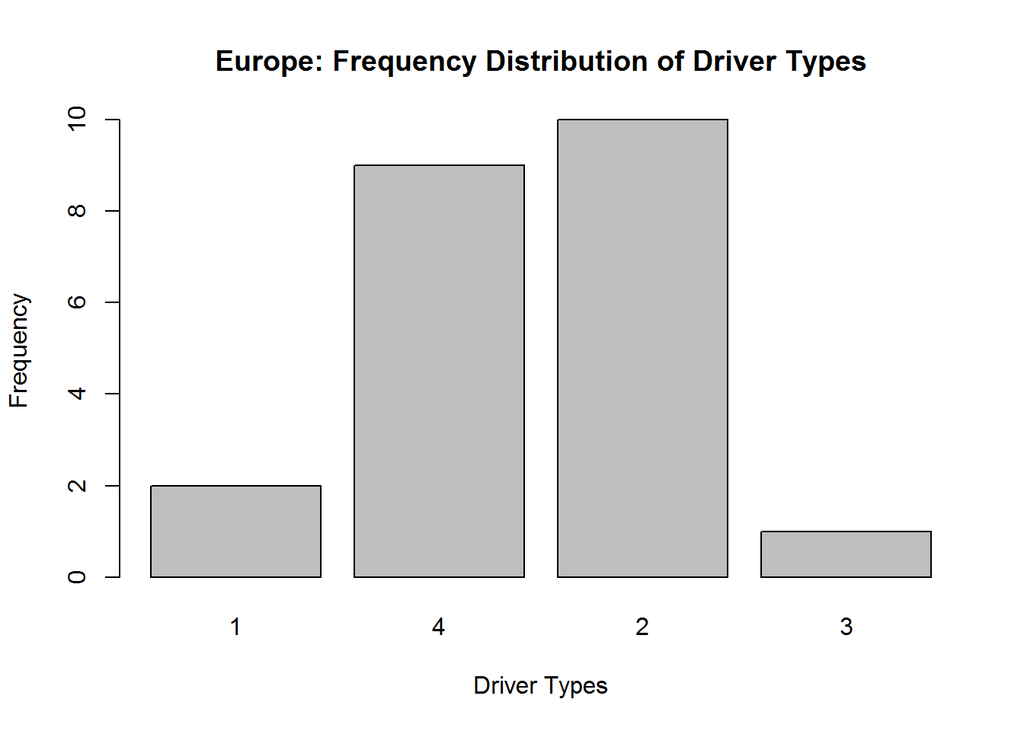

## Joint Probability distribution

```
##         driver_type_ordered
## colour            1          4          2          3
##   Blue   0.09090909 0.00000000 0.04545455 0.04545455
##   Gray   0.00000000 0.00000000 0.09090909 0.00000000
##   Green  0.00000000 0.09090909 0.04545455 0.00000000
##   Red    0.00000000 0.22727273 0.22727273 0.00000000
##   White  0.00000000 0.09090909 0.04545455 0.00000000
##   Yellow 0.00000000 0.00000000 0.00000000 0.00000000
```

```
## [1] 1
```

# Asia data

```
##               DriverID  X..inf...100.       X..100...90.
##  '100000060739145': 1   Min.   :0.000000   Min.   :0.000000
##  '100000559217160': 1   1st Qu.:0.004371   1st Qu.:0.001219
##  '100001160195542': 1   Median :0.014312   Median :0.004074
##  '100001480136118': 1   Mean   :0.017519   Mean   :0.004934
##  '100001563860693': 1   3rd Qu.:0.028685   3rd Qu.:0.008135
##  '100001666930531': 1   Max.   :0.053887   Max.   :0.014793
##  (Other)          :24
##   X..90...80.        X..80...70.        X..70...60.
##  Min.   :0.000000   Min.   :0.000000   Min.   :0.000000
##  1st Qu.:0.002077   1st Qu.:0.003617   1st Qu.:0.005743
##  Median :0.007116   Median :0.009928   Median :0.012800
##  Mean   :0.006786   Mean   :0.009501   Mean   :0.011806
##  3rd Qu.:0.010123   3rd Qu.:0.014357   3rd Qu.:0.015845
##  Max.   :0.015069   Max.   :0.021450   Max.   :0.023658
##
##   X..60...50.         X..50...40.       X..40...30.
##  Min.   :0.0006875   Min.   :0.00275   Min.   :0.003987
##  1st Qu.:0.0086388   1st Qu.:0.01052   1st Qu.:0.014777
##  Median :0.0172359   Median :0.02123   Median :0.029095
##  Mean   :0.0152081   Mean   :0.01874   Mean   :0.024826
##  3rd Qu.:0.0226170   3rd Qu.:0.02471   3rd Qu.:0.032185
##  Max.   :0.0291402   Max.   :0.03266   Max.   :0.043834
##
##   X..30...20.       X..20...10.         X..10..0.         X.0..10.
##  Min.   :0.00483   Min.   :0.005673   Min.   :0.0230   Min.   :0.03661
##  1st Qu.:0.01943   1st Qu.:0.046151   1st Qu.:0.1865   1st Qu.:0.22463
##  Median :0.04025   Median :0.067750   Median :0.2159   Median :0.26097
##  Mean   :0.03551   Mean   :0.058261   Mean   :0.2719   Mean   :0.31837
##  3rd Qu.:0.04683   3rd Qu.:0.074165   3rd Qu.:0.2427   3rd Qu.:0.30341
##  Max.   :0.06218   Max.   :0.087529   Max.   :0.8732   Max.   :0.91276
##
##    X.10..20.          X.20..30.          X.30..40.
##  Min.   :0.008203   Min.   :0.003833   Min.   :0.00391
##  1st Qu.:0.046373   1st Qu.:0.022973   1st Qu.:0.01517
##  Median :0.073066   Median :0.041597   Median :0.02730
##  Mean   :0.063688   Mean   :0.036292   Mean   :0.02443
##  3rd Qu.:0.085877   3rd Qu.:0.046949   3rd Qu.:0.03295
##  Max.   :0.090386   Max.   :0.061312   Max.   :0.04343
##
```

[output cut: 25 more lines]

```
##  1: 4                Min.   :0.00000   Min.   :0.0000   Min.   :0.0000
##  4: 4                1st Qu.:0.00000   1st Qu.:0.0000   1st Qu.:0.0000
##  2:18                Median :0.00000   Median :0.0000   Median :0.0000
##  3: 4                Mean   :0.03333   Mean   :0.2667   Mean   :0.1667
##                      3rd Qu.:0.00000   3rd Qu.:0.7500   3rd Qu.:0.0000
##                      Max.   :1.00000   Max.   :1.0000   Max.   :1.0000
##
##     is_green      is_gray
##  Min.   :0.0   Min.   :0.0000
##  1st Qu.:0.0   1st Qu.:0.0000
##  Median :0.0   Median :0.0000
##  Mean   :0.3   Mean   :0.1667
##  3rd Qu.:1.0   3rd Qu.:0.0000
##  Max.   :1.0   Max.   :1.0000
##
```

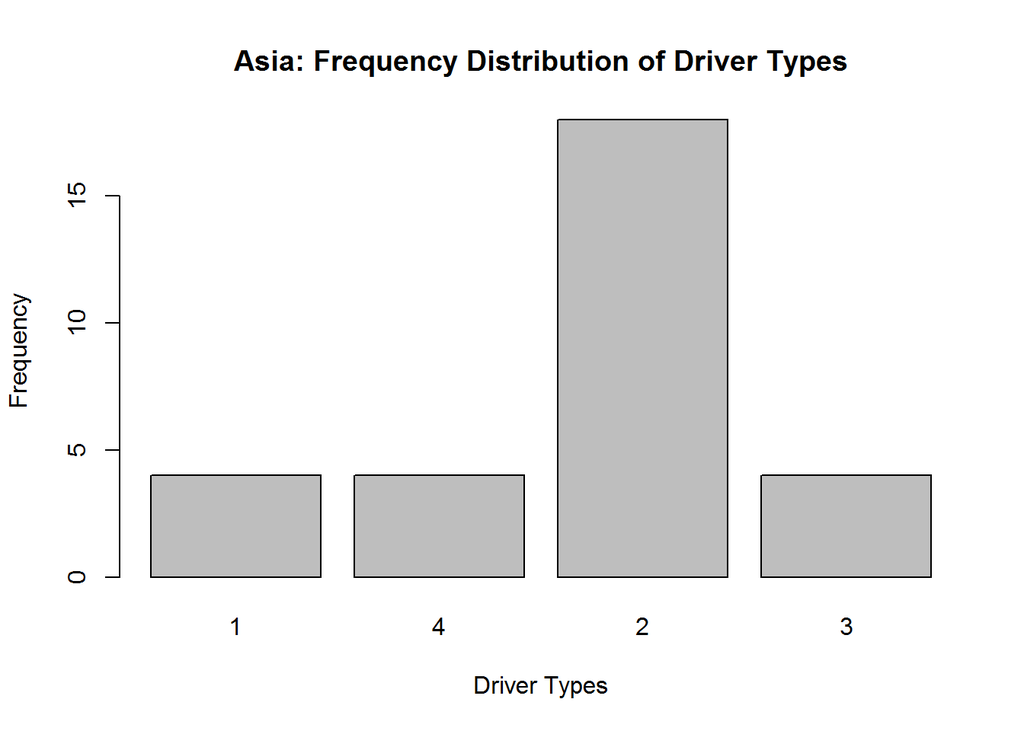

## Joint Probability distribution

```
##         driver_type_ordered
## colour            1          4          2          3
##   Blue   0.03333333 0.00000000 0.06666667 0.06666667
##   Gray   0.00000000 0.00000000 0.13333333 0.03333333
##   Green  0.10000000 0.03333333 0.16666667 0.00000000
##   Red    0.00000000 0.10000000 0.16666667 0.00000000
##   White  0.00000000 0.00000000 0.06666667 0.00000000
##   Yellow 0.00000000 0.00000000 0.00000000 0.03333333
```

# USA data

```
##               DriverID  X..inf...100.       X..100...90.
##  '100000030049306': 1   Min.   :0.000000   Min.   :0.000000
##  '100000420480806': 1   1st Qu.:0.005277   1st Qu.:0.001475
##  '100000546405809': 1   Median :0.010529   Median :0.004394
##  '100000610095990': 1   Mean   :0.019225   Mean   :0.004894
##  '100000722592897': 1   3rd Qu.:0.029081   3rd Qu.:0.005502
##  '100000835424783': 1   Max.   :0.068614   Max.   :0.019022
##  (Other)          :17
##   X..90...80.         X..80...70.         X..70...60.
##  Min.   :0.0003921   Min.   :0.0003438   Min.   :0.001098
##  1st Qu.:0.0024165   1st Qu.:0.0046851   1st Qu.:0.005820
##  Median :0.0054407   Median :0.0066834   Median :0.010025
##  Mean   :0.0070151   Mean   :0.0091808   Mean   :0.011716
##  3rd Qu.:0.0090702   3rd Qu.:0.0127110   3rd Qu.:0.015347
##  Max.   :0.0292120   Max.   :0.0270414   Max.   :0.031929
##
##   X..60...50.         X..50...40.        X..40...30.
##  Min.   :0.0006875   Min.   :0.001412   Min.   :0.001542
##  1st Qu.:0.0092293   1st Qu.:0.012439   1st Qu.:0.022518
##  Median :0.0119918   Median :0.020263   Median :0.027330
##  Mean   :0.0143968   Mean   :0.019541   Mean   :0.028253
##  3rd Qu.:0.0190061   3rd Qu.:0.024151   3rd Qu.:0.038137
##  Max.   :0.0328738   Max.   :0.038043   Max.   :0.044547
##
##   X..30...20.        X..20...10.         X..10..0.          X.0..10.
##  Min.   :0.001961   Min.   :0.003059   Min.   :0.01605   Min.   :0.04273
##  1st Qu.:0.038116   1st Qu.:0.062315   1st Qu.:0.19477   1st Qu.:0.24965
##  Median :0.041440   Median :0.071254   Median :0.24276   Median :0.29541
##  Mean   :0.039187   Mean   :0.065309   Mean   :0.25064   Mean   :0.30715
##  3rd Qu.:0.047591   3rd Qu.:0.078030   3rd Qu.:0.27029   3rd Qu.:0.33247
##  Max.   :0.061392   Max.   :0.091100   Max.   :0.80223   Max.   :0.95804
##
##    X.10..20.          X.20..30.          X.30..40.
##  Min.   :0.003686   Min.   :0.002013   Min.   :0.001699
##  1st Qu.:0.069606   1st Qu.:0.036271   1st Qu.:0.021534
##  Median :0.078399   Median :0.042995   Median :0.026316
##  Mean   :0.071550   Mean   :0.040328   Mean   :0.027838
##  3rd Qu.:0.083580   3rd Qu.:0.048970   3rd Qu.:0.036748
##  Max.   :0.105550   Max.   :0.060709   Max.   :0.047619
##
```

[output cut: 25 more lines]

```
##  1: 1                Min.   :0.00000   Min.   :0.0000   Min.   :0.0000
##  4:12                1st Qu.:0.00000   1st Qu.:0.0000   1st Qu.:0.0000
##  2: 9                Median :0.00000   Median :0.0000   Median :0.0000
##  3: 1                Mean   :0.04348   Mean   :0.4348   Mean   :0.2174
##                      3rd Qu.:0.00000   3rd Qu.:1.0000   3rd Qu.:0.0000
##                      Max.   :1.00000   Max.   :1.0000   Max.   :1.0000
##
##     is_green         is_gray
##  Min.   :0.0000   Min.   :0.00000
##  1st Qu.:0.0000   1st Qu.:0.00000
##  Median :0.0000   Median :0.00000
##  Mean   :0.2174   Mean   :0.04348
##  3rd Qu.:0.0000   3rd Qu.:0.00000
##  Max.   :1.0000   Max.   :1.00000
##
```

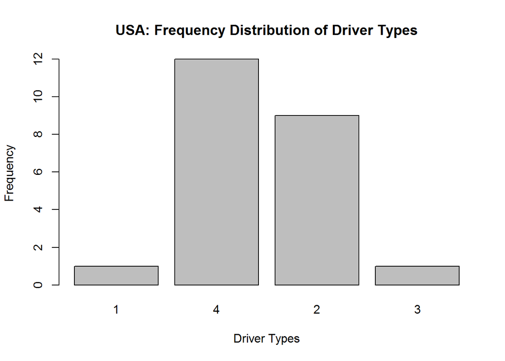

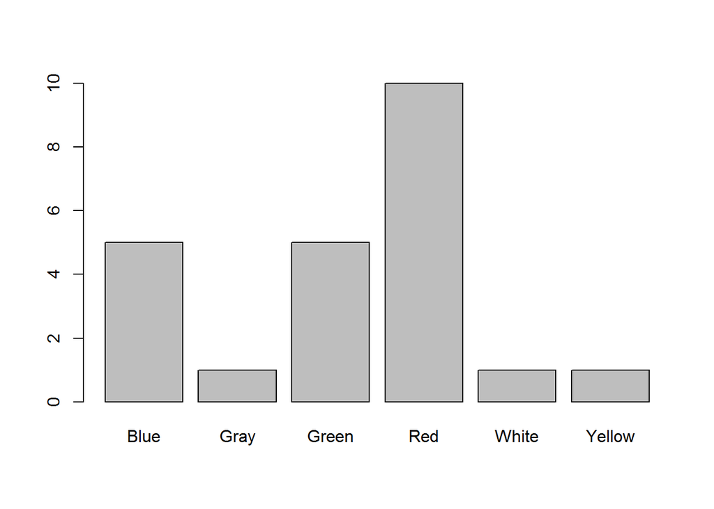

## Joint Probability distribution

```
##         driver_type_ordered
## colour            1          4          2          3
##   Blue   0.04347826 0.13043478 0.04347826 0.00000000
##   Gray   0.00000000 0.00000000 0.04347826 0.00000000
##   Green  0.00000000 0.13043478 0.08695652 0.00000000
##   Red    0.00000000 0.21739130 0.17391304 0.04347826
##   White  0.00000000 0.00000000 0.04347826 0.00000000
##   Yellow 0.00000000 0.04347826 0.00000000 0.00000000
```

# Correlation between painting car “Red” and being “Eco-unfriendly”.

“Eco-unfriendliness is characterized by the levels/ranks”Eco" < “Gentle” < “Normal” < “Crazy”. We are using Kendall correlation coefficient because we are interested in the relationship between the ranks of the variables.

```
Europe data set [1] 0.03739265
```

```
US data set [1] 0.1784349
```

```
Asia data set [1] -0.1577323
```

# Correlation between painting car “Blue” and being “Eco-unfriendly”.

“Eco-unfriendliness is characterized by the levels/ranks”Eco" < “Gentle” < “Normal” < “Crazy”. We are using Kendall correlation coefficient because we are interested in the relationship between the ranks of the variables.

```
Europe data set [1] -0.08689267
```

```
US data set [1] -0.3173891
```

```
Asia data set [1] 0.1871638
```

# Correlation between painting car “Yellow” and being “Eco-unfriendly”.

“Eco-unfriendliness is characterized by the levels/ranks”Eco" < “Gentle” < “Normal” < “Crazy”. We are using Kendall correlation coefficient because we are interested in the relationship between the ranks of the variables.

```
Europe data set Warning in cor(as.numeric(table_europe$driver_type_ordered),
Europe data set table_europe$is_yellow, : the standard deviation is zero
```

```
Europe data set [1] NA
```

```
US data set [1] -0.1561503
```

```
Asia data set [1] 0.2971477
```

# Correlation between painting car “Green” and being “Eco-unfriendly”.

“Eco-unfriendliness is characterized by the levels/ranks”Eco" < “Gentle” < “Normal” < “Crazy”. We are using Kendall correlation coefficient because we are interested in the relationship between the ranks of the variables.

```
Europe data set [1] -0.08680793
```

```
US data set [1] -0.02573425
```

```
Asia data set [1] -0.3402364
```

# Correlation between painting car “Gray” and being “Eco-unfriendly”.

“Eco-unfriendliness is characterized by the levels/ranks”Eco" < “Gentle” < “Normal” < “Crazy”. We are using Kendall correlation coefficient because we are interested in the relationship between the ranks of the variables.

```
Europe data set [1] 0.2590639
```

```
US data set [1] 0.2082003
```

```
Asia data set [1] 0.2312024
```